# Shiny for Bioinformatics Tutorial

Mark Dunning

Last modified: 02 Aug 2017

# A use-case in Genomics

We are going to develop a simple app to allow a user to perform statistical tests and generate plots from a published dataset. This seems to be quite a common use-case and can be automated through Shiny in a relatively painless manner. We will be using the [breastCancerNKI](http://bioconductor.org/packages/release/data/experiment/html/breastCancerNKI.html) dataset, which is already available as part of Bioconductor. If you didn’t install this already, you will need to do:-

```r
source("http://www.bioconductor.org/biocLite.R")
biocLite("breastCancerNKI")
```

Briefly, this dataset comprises the gene expression profiling of breast cancer patients. There is extensive clinical data available, but we will be focusing on the ER (Estrogen Receptor) status of each patient. This variable (either positive or negative) is known to predict survival.

The UI for the app will contain a drop-down where the user can type the name of the gene they wish to interrogate. We will give a limited set of options and a default value of `ESR1`, which we expect to show a significant difference between the conditions.

```r
ui <- fluidPage(

   # Application title
   titlePanel("Interrogating the NKI breast cancer dataset"),

   sidebarLayout(
      sidebarPanel(
         selectInput("thegene","Gene to Analyse",
                     choices=c("ESR1","ERBB2","PTEN"),
                       selected  = "ESR1")
      ),

      # Show a plot of the generated distribution
      mainPanel(
         plotOutput("boxplot")
      )
   )
)
```

The `server` code has to deal with loading the Bioconductor package and creating data objects that we can interrogate. The standard way to access data from an experimental data package involves the use of the functions `exprs` (to get expression values), `fData` (for gene annotation) and `pData` (for sample annotations).

Note that this code only needs to be run once for the initial setup of the app. It could be placed in a separate script and run with the `source(...)` function to make the code a bit cleaner.

We could also include code here for loading R objects or reading from a file as required.

```r
  library(breastCancerNKI)
  library(Biobase)
  data(nki)
  expression.values <- exprs(nki)
  features <- fData(nki)
  er.status <- pData(nki)$er
```

The matrix `expression.values` contains the values we would like to plot and the `er.status` vector is the categorical variable corresponding to ER status.

```r
table(er.status)
```

```
## er.status
##   0   1
##  88 249
```

```r
expression.values[1:5,1:5]
```

```
##                 NKI_4  NKI_6  NKI_7  NKI_8  NKI_9
## Contig45645_RC -0.215  0.071  0.182 -0.343 -0.134
## Contig44916_RC -0.207  0.055  0.077  0.302  0.051
## D25272         -0.158 -0.010  0.059  0.169 -0.007
## J00129         -0.819 -0.391 -0.624 -0.528 -0.811
## Contig29982_RC -0.267 -0.310 -0.120 -0.447 -0.536
```

To make a boxplot of the expression level of a particular gene, we can use the formula syntax in R

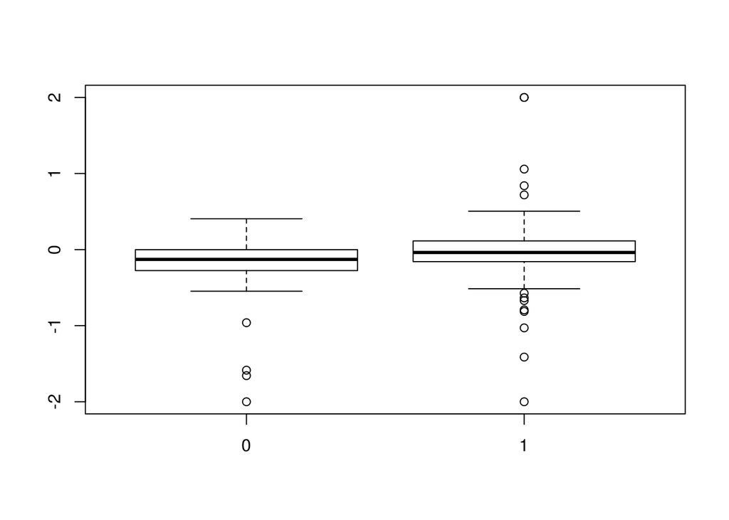

```r
boxplot(expression.values[1,] ~ er.status)
```

A slight complication is that the rows of the expression matrix are the manufacturer identifier and the user is going to be inputting a gene name (gene symbol). So to identify the gene we are interested in (`ESR1` for example) we have to perform a mapping via the `features` matrix.

```r
features[1:5,1:5]
```

```
##                         probe EntrezGene.ID     probe.name Alignment.score
## Contig45645_RC Contig45645_RC         64388 Contig45645_RC              60
## Contig44916_RC Contig44916_RC        140883 Contig44916_RC              60
## D25272                 D25272            NA           <NA>              NA
## J00129                 J00129          2244         J00129              60
## Contig29982_RC Contig29982_RC        286133 Contig29982_RC              60
##                Length.of.probe
## Contig45645_RC              60
## Contig44916_RC              60
## D25272                      NA
## J00129                      60
## Contig29982_RC              60
```

The relevant column in `features` is `HUGO.gene.symbol` and we will use the `match` function to check which rows match a particular bit of text. To keep things simple, we will ignore the fact that a gene might have more than one probe.

```r
probe.id <- as.character(features$probe[match(gene, features$HUGO.gene.symbol)])
values <- expression.values[probe.id,]
```

The code for the app then becomes:-

```r
library(shiny)

ui <- fluidPage(

   # Application title
   titlePanel("Interrogating the NKI breast cancer dataset"),

   sidebarLayout(
      sidebarPanel(
         selectInput("thegene","Gene to Analyse",
                     choices=c("ESR1","ERBB2","PTEN"),
                       selected  = "ESR1")
      ),

      # Show a plot of the generated distribution
      mainPanel(
         plotOutput("boxplot")
      )
   )
)

server <- function(input, output) {

  library(breastCancerNKI)

  data(nki)
  expression.values <- exprs(nki)
  features <- fData(nki)
  er.status <- pData(nki)$er

   output$boxplot <- renderPlot({

     gene <- input$thegene
     probe.id <- as.character(features$probe[match(gene, features$HUGO.gene.symbol)])

     values <- expression.values[probe.id,]
     boxplot(values ~ er.stats)
   })

}

# Run the application
shinyApp(ui = ui, server = server)
```

[interactive chart not shown]

## Customising the plot

As we have seen previously, we can also add options to allow the user to customise the appearance of the plot

```r
library(shiny)

ui <- fluidPage(

   # Application title
   titlePanel("Interrogating the NKI breast cancer dataset"),

   sidebarLayout(
      sidebarPanel(
         selectInput("thegene","Gene to Analyse",
                     choices=c("ESR1","ERBB2","PTEN"),
                       selected  = "ESR1"),
                 radioButtons("colour","Colour of histogram",choices=c("red","green","blue"),selected="red")
      ),

      # Show a plot of the generated distribution
      mainPanel(
         plotOutput("boxplot")
      )
   )
)

server <- function(input, output) {

  library(breastCancerNKI)

  data(nki)
  expression.values <- exprs(nki)
  features <- fData(nki)
  er.status <- pData(nki)$er

   output$boxplot <- renderPlot({

     gene <- input$thegene
     probe.id <- as.character(features$probe[match(gene, features$HUGO.gene.symbol)])

     values <- expression.values[probe.id,]
     boxplot(values ~ er.status,col=input$colour)
   })

}

# Run the application
shinyApp(ui = ui, server = server)
```

[interactive chart not shown]

## Introducing “reactives”

https://shiny.rstudio.com/tutorial/lesson6/

Unfortunately, we have introduced some inefficiency into our app. The code inside the `renderPlot` function will be triggered whenever the user changes the options for the gene name or the color of the plot. This code includes the steps to filter the expression data based on the gene that is currently selected. It make sense for this code to be re-run when a new gene is selected, but not if a different colour is selected (which is the current state of affairs).

A solution is to define a *reactive* function. These are special functions in `shiny` that caches it’s values, and will only be re-run when any of these values become outdated.

The functions can be called from within other functions inside the server script. For example, code that creates a plot. The first time the function is called, the output values are stored in memory. The next time the function is called, the function will check if any of the inputs have been updated. If not, the results of the previous calculation will be returned. This is ideal behaviour in the situation we have described.

In our example, we might define a function `filterByExpression` which basically contains the steps we already had inside the boxplot code. The last line of the function defines the object that is returned.

Within the `renderPlot` function we can call the `filterByExpression` function to retrieve the values for a particular gene.

We add a `Sys.sleep()` statement to help illustrate the fact that `filterByExpression` is only run when the name of the gene is changed by the user.

```r
server <- function(input, output) {

  library(breastCancerNKI)

  data(nki)
  expression.values <- exprs(nki)
  features <- fData(nki)
  er.status <- pData(nki)$er

  filterByExpression <- reactive({
     gene <- input$thegene
     probe.id <- as.character(features$probe[match(gene, features$HUGO.gene.symbol)])
      Sys.sleep(10)
     expression.values[probe.id,]
  })

   output$boxplot <- renderPlot({

     gene <- input$thegene
     probe.id <- as.character(features$probe[match(gene, features$HUGO.gene.symbol)])

     values <- filterByExpression()

     boxplot(values ~ er.status,col=input$colour)
   })

}
```

Try changing the values for gene name and boxplot colour in the following shiny app.

[interactive chart not shown]